# double-gap RC data cleaning & analysis (exp1)

This document walks you through how to clean and analyze the data for the double-RC experiment (Experiment 1).

## Packages used

We use the following packages in order to import and clean the data.

```r
library(tidyverse)
library(ibextor)
library(lmerTest)
```

## Data cleaning

### Import the data

We use the package `ibextor`’s functions in order to parse the data from Ibexfarm with irrelevant parts/lines removed.

```r
#getting the results
results1 = get_results_aj('raw_results_batch1.csv')
results2 = get_results_aj('raw_results_batch2.csv')
results3 = get_results_aj('raw_results_batch3.csv')
results4 = get_results_aj('raw_results_batch4.csv')

#getting subject data
subj1 = get_subj_info('raw_results_batch1.csv')
subj2 = get_subj_info('raw_results_batch2.csv')
subj3 = get_subj_info('raw_results_batch3.csv')
subj4 = get_subj_info('raw_results_batch4.csv')
```

### Adding sentence type information for batch 1 results

Due to an error, we failed to record the specific type of each sentence (it only says ‘e’ for critical items) for batch 1. The following code fixes that:

```r
stimuli.list = read.csv('stimuli.list.csv')
for (i in 1:nrow(results1)) {
  if(results1$sentence[i] %in% stimuli.list$e.ext.RC){
    results1$type[i] = 'e.ext.RC'
} else if(results1$sentence[i] %in% stimuli.list$e.nonext.RC){
    results1$type[i] = 'e.nonext.RC'
} else if(results1$sentence[i] %in% stimuli.list$e.ext.nonRC){
    results1$type[i] = 'e.ext.nonRC'
} else if(results1$sentence[i] %in% stimuli.list$e.nonext.nonRC){
    results1$type[i] = 'e.nonext.nonRC'
  }
}
```

### Modify subject IDs

Before combining data, let’s reassign subject IDs so that all will be unique.

```r
results1$subj = as.numeric(results1$subj)
subj1$subj = 1:21

results2$subj = as.numeric(results2$subj)+21
subj2$subj = 22:31

results3$subj = as.numeric(results3$subj)+31
subj3$subj = 32:47

results4$subj = as.numeric(results4$subj)+47
subj4$subj = 48:60
```

### Combine the data

For a counterbalancing reason, the experiment was run in several batches with different list assignments. Let’s combine the data together:

```r
AJ.data = bind_rows(results1, results2, results3, results4)
subject.data = bind_rows(subj1, subj2, subj3, subj4)
```

### Filter out unapproved subjects

Because not all the subjects in the data were approved of their submissions (due to technical issues, multiple submissions, etc.), the following code filters out the subjects whose submission was unapproved.

```r
#create a vector of approved subjects' IDs
approval.list = read.csv('approval.list.csv')
approved.subj = c()
for (i in 1:nrow(approval.list)) {
  if(approval.list$approved[i] == 1){
    approved.subj[i] = approval.list$subj[i]}
}
approved.subj = approved.subj[!is.na(approved.subj)]
```

```r
AJ.data.clean = AJ.data %>% filter(subj %in% approved.subj)
```

### Pre-processing

The following code converts the datatype of some variables, and fixes the numbers in the `answer` columns from full-width to half-width.

```r
AJ.data.clean$subj = as.factor(AJ.data.clean$subj)
AJ.data.clean$sentence = as.character(AJ.data.clean$sentence)
AJ.data.clean$answer = as.numeric(stringi::stri_trans_nfkc(AJ.data.clean$answer))
```

### Normalize acceptability scores

```r
AJ.data.clean = AJ.data.clean %>%
  group_by(subj) %>%
  mutate(z.score = (answer - mean(answer)) / sd(answer))

AJ.data.clean$z.score[is.nan(AJ.data.clean$z.score)] = 0
```

### flag subjects with an unexpected pattern of judgments for unanimously good/bad fillers

First, we’ll create a dataset of fillers including individual z-scores and mean & sd of each filler. The dataset is then filtered to contain only the fillers that had particularly high or low mean z-scores (i.e., fillers where the judgments were unanimously good or bad).

```r
filtering = AJ.data.clean %>%
  filter(type == 'filler' | type == 'practice') %>%
  group_by(sentence) %>%
  mutate(mean.answer = mean(answer),
         mean.answer.z = mean(z.score),
         sd.answer.z = sd(z.score)) %>%
  arrange(mean.answer.z) %>%
  ungroup()

filtering = filtering %>%
  filter(mean.answer.z < quantile(mean.answer.z, .25) | mean.answer.z > quantile(mean.answer.z, .75))
```

The next code flags any subjects whose z-scores are more than 2 standard deviations away from the mean for such good and bad fillers.

```r
flag.list = c()
sents = c()
for (i in 1:nrow(filtering)) {
  if(abs(filtering$z.score[i] - filtering$mean.answer.z[i]) >= filtering$sd.answer.z[i]*2){
    flag.list[i] = levels(droplevels(filtering$subj[i]))
    sents[i] = filtering$sentence[i]
  }
}

flag.list = flag.list[!is.na(flag.list)]
sents = sents[!is.na(sents)]
flag.list = cbind(flag.list,sents)
flag.list = as.data.frame(flag.list)
flag.list = flag.list %>% rename(subj = flag.list)
flag.list.summary = flag.list %>% count(subj)
```

The dataframe `flag.list.summary` shows that two subjects provided erratic judgments to 11 out of 20 extreme fillers, and the following code exclude the two subjects.

```r
AJ.data.clean = AJ.data.clean %>% filter(!(subj %in% c(10,32)))
```

### Remove more subjects for counterbalancing purpose

As you can see below, the counterbalancing is still imperfect (i.e., there are unequal # of subjects assigned to each list).

```r
lex.list = AJ.data.clean %>% group_by(type) %>% count(item) #lex stands for lexicalization
lex.list = lex.list[order(lex.list$item),]
lex.list
```

```
## # A tibble: 82 x 3
## # Groups:   type [6]
##    type           item      n
##    <chr>          <fct> <int>
##  1 e.ext.nonRC    1         9
##  2 e.ext.RC       1        14
##  3 e.nonext.nonRC 1         9
##  4 e.nonext.RC    1        10
##  5 e.ext.nonRC    10       10
##  6 e.ext.RC       10        9
##  7 e.nonext.nonRC 10        9
##  8 e.nonext.RC    10       14
##  9 e.ext.nonRC    11       14
## 10 e.ext.RC       11        9
## # … with 72 more rows
```

Thus, the code below removes several subjects (those who completed the survey last) so as to make sure that the final data comes from exactly 9 subjects assigned to each list.

```r
AJ.data.final = AJ.data.clean %>% filter(!(subj %in% c(11,12,13,14,16,17,21)))
```

## Data description & visualization

### Provide a descriptive summary of data

## Critical items

```r
AJ.data.final.summary = AJ.data.final %>%
  group_by(type) %>%
  summarise(mean = mean(answer), mean.z = mean(z.score),
            sd = sd(answer), sd.z = sd(z.score),
            se = sd(answer)/sqrt(36), se.z = sd(z.score)/sqrt(36))
AJ.data.final.summary
```

```
## # A tibble: 6 x 7
##   type            mean  mean.z    sd  sd.z    se   se.z
##   <chr>          <dbl>   <dbl> <dbl> <dbl> <dbl>  <dbl>
## 1 e.ext.nonRC     5.04  0.389   1.68 0.688 0.280 0.115
## 2 e.ext.RC        4.28  0.0607  1.78 0.748 0.297 0.125
## 3 e.nonext.nonRC  6.06  0.877   1.26 0.481 0.210 0.0802
## 4 e.nonext.RC     5.99  0.851   1.44 0.605 0.239 0.101
## 5 filler          3.49 -0.265   2.27 1.00  0.379 0.167
## 6 practice        3.49 -0.276   2.05 0.912 0.341 0.152
```

## Fillers

The following code labels a filler as good, intermediate, or bad (there are 10, 10, and 20 of them, 40 total), and makes sure that the mean acceptability is in line with the categorization.

```r
filler.list = read.csv('filler.list.csv')
AJ.data.final.fillers = AJ.data.final %>% filter(type == 'filler' | type == 'practice')

AJ.data.final.fillers$level = NA
for (i in 1:nrow(AJ.data.final.fillers)) {
  if(AJ.data.final.fillers$sentence[i] %in% filler.list$high){
    AJ.data.final.fillers$level[i] = 'good'
} else if(AJ.data.final.fillers$sentence[i] %in% filler.list$middle){
    AJ.data.final.fillers$level[i] = 'intermediate'
} else if(AJ.data.final.fillers$sentence[i] %in% filler.list$low){
    AJ.data.final.fillers$level[i] = 'bad'
} else if(AJ.data.final.fillers$sentence[i] %in% filler.list$other){
    AJ.data.final.fillers$level[i] = 'other' #a practice item; will be excluded from a summary below
  }
}

AJ.data.final.fillers %>% filter(!(level == 'other')) %>%
  group_by(level) %>%
  summarize(mean = mean(z.score))
```

```
## # A tibble: 3 x 2
##   level          mean
##   <chr>         <dbl>
## 1 bad          -0.860
## 2 good          1.03
## 3 intermediate -0.451
```

### Visualize the data

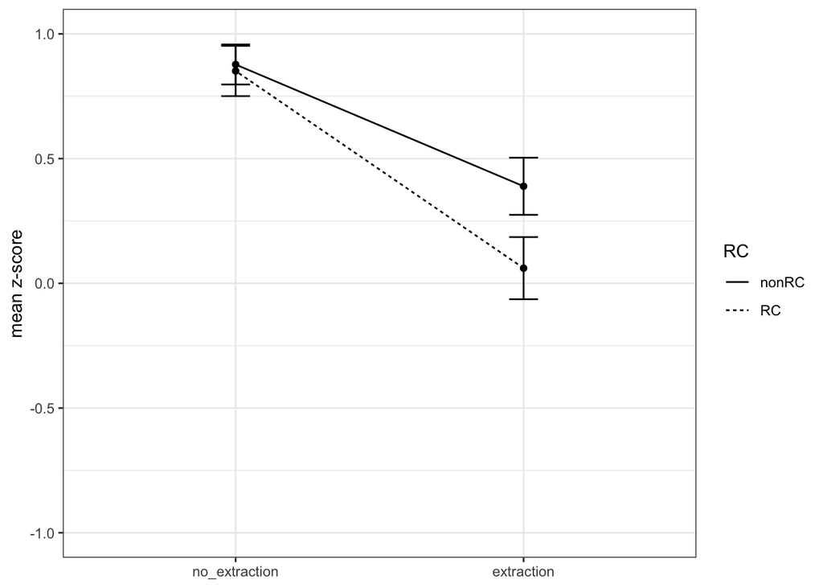

```r
columns = data.frame(extraction=c('extraction', 'extraction', 'no_extraction', 'no_extraction', 'na', 'na'),
                     RC=c('nonRC','RC','nonRC','RC', 'na', 'na'))
AJ.data.final.summary = cbind(columns, AJ.data.final.summary)
AJ.data.final.summary$extraction = factor(AJ.data.final.summary$extraction,
                                          levels = rev(levels(AJ.data.final.summary$extraction)))

AJ.data.final.summary %>% filter(!(extraction =='na')) %>%
  ggplot(aes(x=extraction, y=mean.z))+
  geom_point()+
  geom_path(aes(group = RC, linetype = RC))+
  geom_errorbar(aes(ymin=mean.z-se.z, ymax=mean.z+se.z), width=0.1)+
  ylab('mean z-score')+
  expand_limits(y = c(-1, 1))+
  theme_bw()+
  theme(axis.title.x=element_blank())
```

## Testing for significance

We’ll use the package `lmerTest` to test for the significance of main effects of RC and extraction, and more importantly, the interaction effect between the two.

First, we will create two colums specifying the existence of extraction and RC.

```r
AJ.data.final = AJ.data.final %>% filter(!(type == 'filler' | type == 'practice'))
AJ.data.final$extraction = NA
AJ.data.final$RC = NA
for (i in 1:nrow(AJ.data.final)) {
  if(AJ.data.final$type[i] == 'e.ext.RC'){
    AJ.data.final$extraction[i] = 1
    AJ.data.final$RC[i] = 1
  } else if(AJ.data.final$type[i] == 'e.ext.nonRC') {
    AJ.data.final$extraction[i] = 1
    AJ.data.final$RC[i] = 0
  } else if(AJ.data.final$type[i] == 'e.nonext.RC') {
    AJ.data.final$extraction[i] = 0
    AJ.data.final$RC[i] = 1
  } else if(AJ.data.final$type[i] == 'e.nonext.nonRC') {
    AJ.data.final$extraction[i] = 0
    AJ.data.final$RC[i] = 0
  }
}
AJ.data.final$extraction = as.factor(AJ.data.final$extraction)
AJ.data.final$RC = as.factor(AJ.data.final$RC)
```

Below is the code for a mixed-effects model fit to analyze the data. As the maximal model did not converge, one interaction term has been removed. The model reveals a significant main effect of extraction, as well as a significant interaction effect.

```r
lmer.model = lmer(z.score ~ extraction*RC + (1+extraction*RC | subj) + (1+extraction+RC | item),
                  data = AJ.data.final)
summary(lmer.model)
```

```
## Linear mixed model fit by REML. t-tests use Satterthwaite's method [
## lmerModLmerTest]
## Formula: z.score ~ extraction * RC + (1 + extraction * RC | subj) + (1 +
##     extraction + RC | item)
##    Data: AJ.data.final
##
## REML criterion at convergence: 1277.7
##
## Scaled residuals:
##     Min      1Q  Median      3Q     Max
## -3.7015 -0.4709  0.1269  0.6081  2.3333
##
## Random effects:
##  Groups   Name            Variance Std.Dev. Corr
##  subj     (Intercept)     0.02583  0.1607
##           extraction1     0.09482  0.3079   -0.11
##           RC1             0.03809  0.1952   -0.48 -0.36
##           extraction1:RC1 0.06417  0.2533    0.23 -0.23 -0.40
##  item     (Intercept)     0.04321  0.2079
##           extraction1     0.07351  0.2711   -0.29
##           RC1             0.06266  0.2503   -0.24  0.05
##  Residual                 0.26738  0.5171
## Number of obs: 720, groups:  subj, 36; item, 20
##
## Fixed effects:
##                 Estimate Std. Error       df t value Pr(>|t|)
## (Intercept)      0.87731    0.06606 26.14980  13.281 3.91e-13 ***
## extraction1     -0.48821    0.09633 35.35464  -5.068 1.27e-05 ***
## RC1             -0.02598    0.08463 31.42141  -0.307  0.76092
## extraction1:RC1 -0.30239    0.08789 33.11091  -3.441  0.00159 **
## ---
## Signif. codes:  0 '***' 0.001 '**' 0.01 '*' 0.05 '.' 0.1 ' ' 1
##
## Correlation of Fixed Effects:
##             (Intr) extrc1 RC1
## extraction1 -0.386
## RC1         -0.455  0.129
## extrct1:RC1  0.301 -0.410 -0.474
```